# Part II - Explanatory Analysis of Prosper Loan Data

## by Prince G Sibanda

## Investigation Overview

> The project is aimed at figuring out the factors that influence the loan status (defaulting of loans and loan approval)

## Dataset Overview

> LoanOriginalAmount  
> MonthlyLoanPayment  
> TotalProsperLoans  
> ProsperRating_Alpha  
> ProsperScore  
> LoanStatus  
> Year  
> Month

## Yearly distribution of loans

The number of listings has been increasing since July 2009 to 2013 where 2013 recorded the highest number of loan listings. A sharp decline was experienced in 2014 and no information is available to explain this fall.

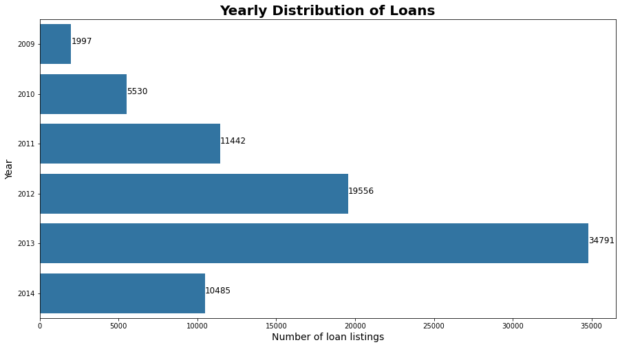

## Distribution of Loan Terms

The Term with the highest number of loan listings is 36 months followed by 60 months and lastly 12 months.

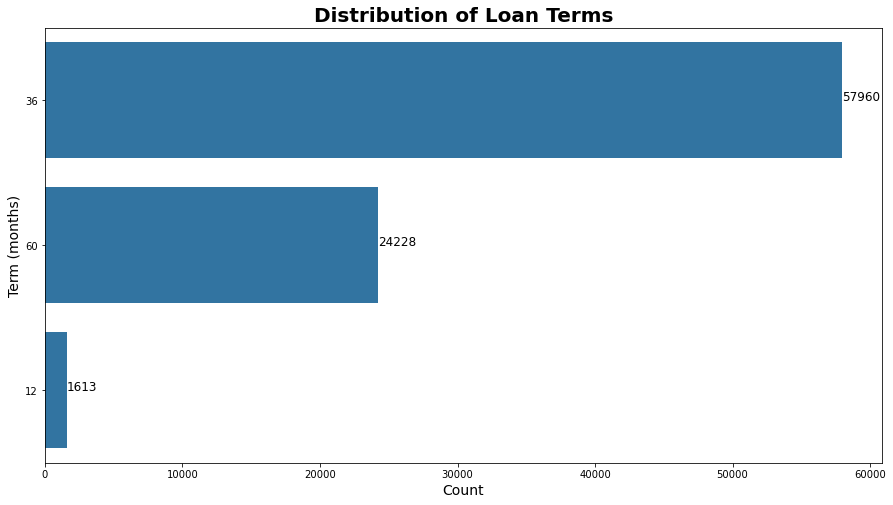

## Relationship between employment status and term

36 months is the highest recorded term followed by 60 months. Most employed and and full time borrowers took the 36 month term to settle the loan.

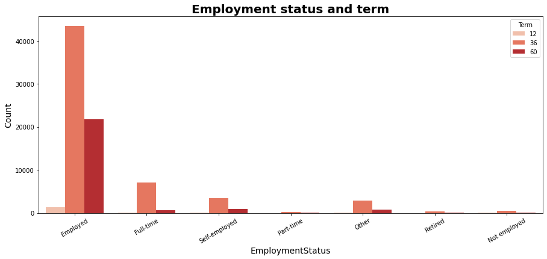

## Average Monthly income by Occupation

Top 5 earning occupations on a monthly basis are : doctor, attorney, executive, judge and dentist

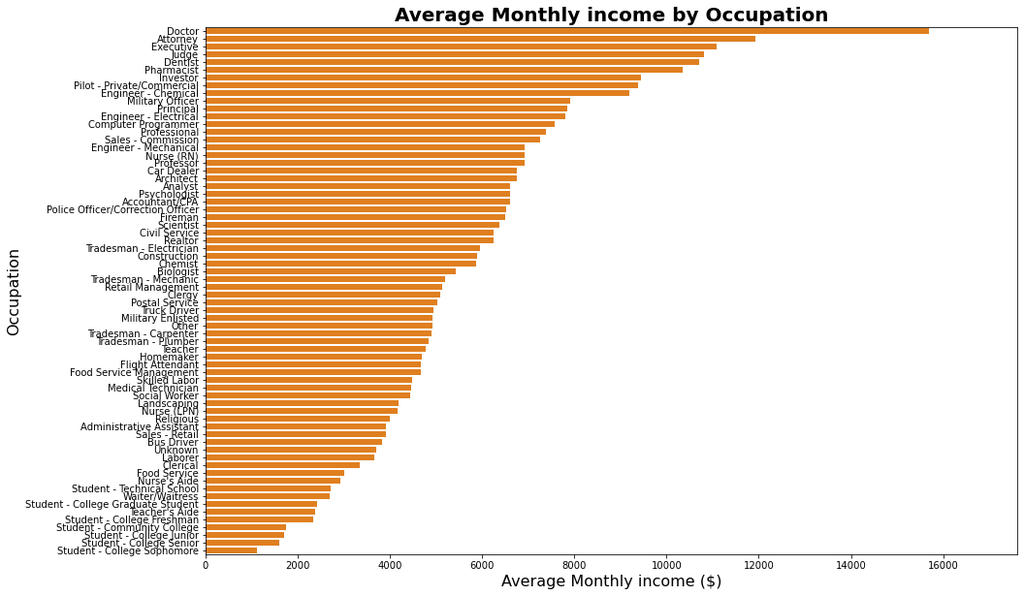

## How does ProsperRating_Alpha relate to BorrowerRate on termly basis?

Borrowers with the relatively high prosper ratings (high eligible for approval of loans)enjoy the benefit of lower interest however interest rate increases slightly with increase in terms from 12 month to 36 months to 60 months

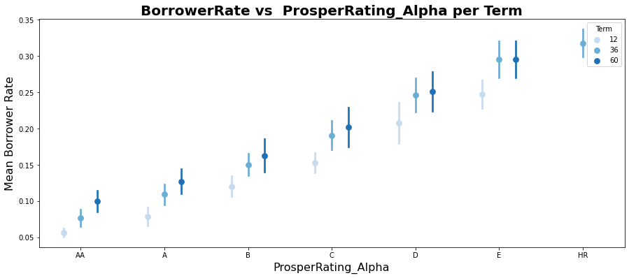

## How does LoanStatus relate to BorrowerRate on termly basis?

Current loans have lower interest rates as opposed to the defaulted ones ranging above 0.2 to 0.25.

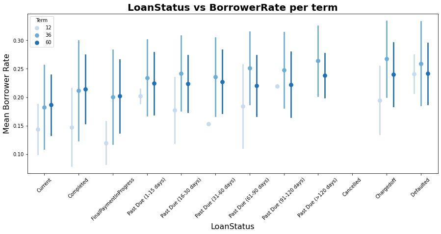

## Borrower rate vs EmploymentStatus vs Term

The employed and full time borrowers have relatively lower interest rates which increase fairly with change in terms with 12 month term having the lowest and 36 months having the highest rate. it is important to not that on a 60 month term, the retired borrowers have the lowest rate amongst other groups in that category.

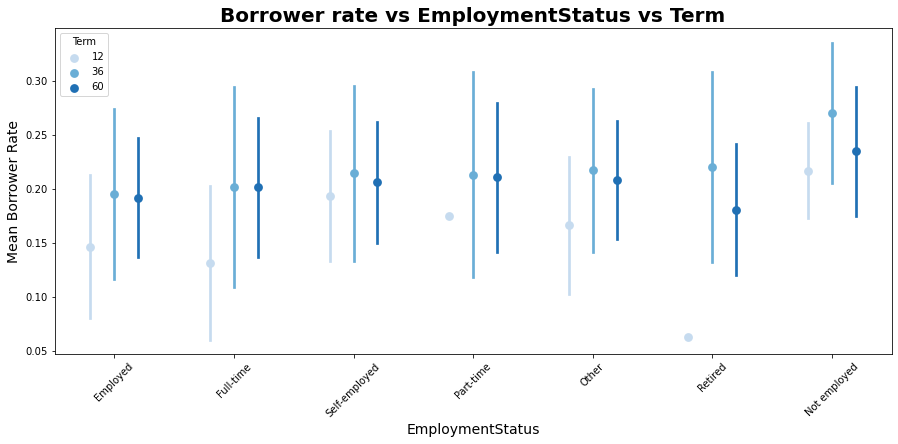

## BorrowerAPR vs BorrowerRate per ProsperRating_Alpha

The higher the ProsperRatings the lower the Borrower ratings making borrowers with such ratings unlikely to default on their loan repayment.

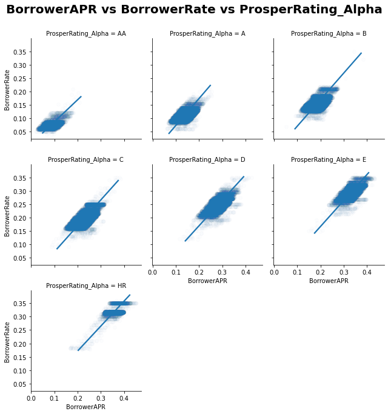

## EmploymentStatus vs ProsperRating_Alpha vs Loanstatus

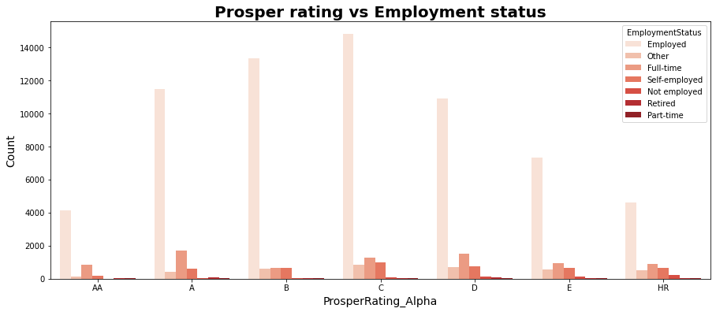

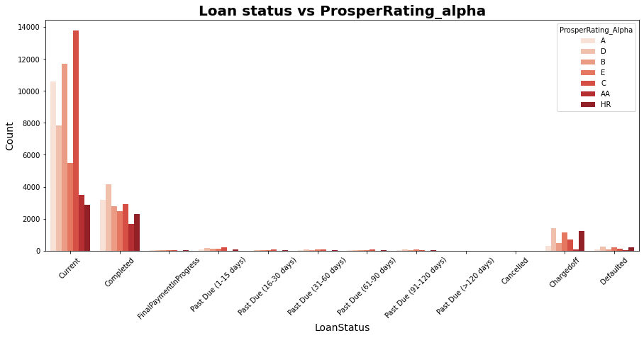